# Targeted groups of fungi based on their moisture requirements for growth and their abundances across homes with moisture damage

Rachel Adams

2/11/2021

## Motivation

There is no quantifiable microbiological measurement that indicates building dampness. In this work, we hypothesized that particular groups of fungi, targeted based on the moisture requirements that they need to grow, are elevated in damaged buildings compared to dry buildings. This documents shows the methods used to isolate the fungi of interest from the entire fungal community and the statistical tests used to test the hypothesis.

This work was published in: Adams, R. I., Sylvain, I., Spilak, M. P., Taylor, J. W., Waring, M. S., & Mendell, M. J. (2020). Fungal signature of moisture damage in buildings: identification by targeted and untargeted approaches with mycobiome data. Applied and Environmental Microbiology, 86(17).

## Preparation and input

### Load needed packages (not shown)

### Input data

The starting input is a phyloseq object (https://joey711.github.io/phyloseq/index.html), which has three components: an OTU/ASV table, sample (meta)data, and taxonomic information.

```r
setwd("~/Desktop/Targeted-fungi")
ps = readRDS("~/Desktop/Targeted-fungi/data/ps.rds")
ps
```

```
## phyloseq-class experiment-level object
## otu_table()   OTU Table:         [ 24335 taxa and 467 samples ]
## sample_data() Sample Data:       [ 467 samples by 16 sample variables ]
## tax_table()   Taxonomy Table:    [ 24335 taxa by 7 taxonomic ranks ]
```

Many environmental samples were taken per home, but building damage was determined by the house. Later, we'll have to link the metadata associated with the sample with the building assessment recorded in another input table.

```r
house_meta = read.table("~/Desktop/Targeted-fungi/data/house_metadata.txt",
    header = TRUE)
```

```r
target.aw = read.csv("~/Desktop/Targeted-fungi/data/moist_req_fungi.csv",
    header = TRUE)
# dim(target.aw)
head(target.aw)
```

```
##                     taxa mean_min_aw min_aw
## 1 Sistotrema_brinkmannii        0.97   0.97
## 2     Rhizoctonia_solani        0.96   0.96
## 3    Chaetomium_globosum        0.94   0.94
## 4       Botrytis_cinerea        0.93   0.93
## 5         Mucor_plumbeus        0.93   0.93
## 6         Phoma_herbarum        0.93   0.93
```

We group the fungi into groups based on their minimum growth requirements.  
xerophiles: 0.65 < aw <= 0.80  
mesophiles: 0.80 >= aw < 0.90  
hydrophiles: aw >= 0.90

```r
hydro_level = 0.9
xero_level = 0.8

target.hydro = target.aw[target.aw$mean_min_aw >= hydro_level, ]
target.meso = target.aw[target.aw$mean_min_aw >= xero_level & target.aw$mean_min_aw <
    hydro_level, ]
target.xero = target.aw[target.aw$mean_min_aw < xero_level, ]
```

### Produce individual phyloseq objects with just the taxa of interest.

First, match up the formatting of the species names between the phyloseq object and the important list of taxa you care about. Then get different phyloseq objects of just the taxa that you care about.

```r
# create data frame to work with, in order to get taxonomic identity in
# Genus_species format gs=as.data.frame(tax_table(ps)[,6:7]) #this is a
# slow step, so inporting previously-saved object
# saveRDS(gs,'~/Desktop/Targeted-fungi/data/genus_species.RDS')
gs = readRDS("~/Desktop/Targeted-fungi/data/genus_species.RDS")

# create new column drawing on the existing columns and put in correct
# Genus_species format
gs[, "Genus_species"] = paste(substring(gs$Genus, 4, ), "_", gsub("s__",
    "\\1", gs$Species), sep = "")

# get subsetted data frame of those ASVs that are hydrophiles
gs.target.hydro = gs[(gs[, "Genus_species"] %in% target.hydro$taxa), ]
# get new phyloseq table with just hydrophiles
ps.target.hydro = prune_taxa(as.vector(rownames(gs.target.hydro)), ps)
ps.target.hydro
```

```
## phyloseq-class experiment-level object
## otu_table()   OTU Table:         [ 118 taxa and 467 samples ]
## sample_data() Sample Data:       [ 467 samples by 16 sample variables ]
## tax_table()   Taxonomy Table:    [ 118 taxa by 7 taxonomic ranks ]
```

```r
# get subsetted data frame of those ASVs that are mesophiles
gs.target.meso = gs[(gs[, "Genus_species"] %in% target.meso$taxa), ]
# get new phyloseq table with just mesophiles
ps.target.meso = prune_taxa(as.vector(rownames(gs.target.meso)), ps)
ps.target.meso
```

```
## phyloseq-class experiment-level object
## otu_table()   OTU Table:         [ 234 taxa and 467 samples ]
## sample_data() Sample Data:       [ 467 samples by 16 sample variables ]
## tax_table()   Taxonomy Table:    [ 234 taxa by 7 taxonomic ranks ]
```

```r
# get subsetted data frame of those ASVs that are xerophiles
gs.target.xero = gs[(gs[, "Genus_species"] %in% target.xero$taxa), ]
# get new phyloseq table with just xerophiles
ps.target.xero = prune_taxa(as.vector(rownames(gs.target.xero)), ps)
ps.target.xero
```

```
## phyloseq-class experiment-level object
## otu_table()   OTU Table:         [ 153 taxa and 467 samples ]
## sample_data() Sample Data:       [ 467 samples by 16 sample variables ]
## tax_table()   Taxonomy Table:    [ 153 taxa by 7 taxonomic ranks ]
```

Checking out the abundances of the different groups across the samples. There are more mesophiles observed in the community, by a lot.

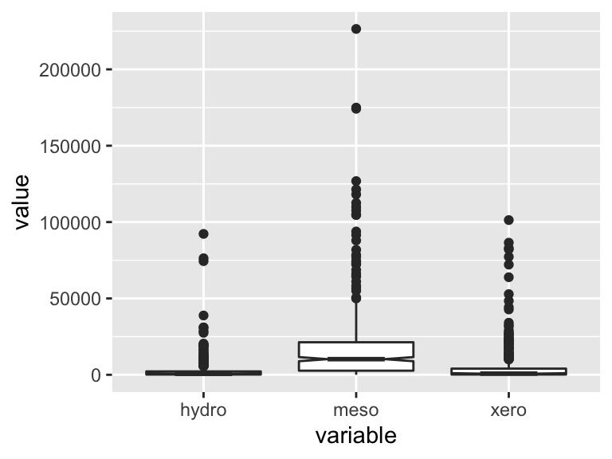

```r
sampsums_groups = melt(bind_cols(sample_name = sample_names(ps.target.hydro),
    hydro = sample_sums(ps.target.hydro), meso = sample_sums(ps.target.meso),
    xero = sample_sums(ps.target.xero)), id.vars = "sample_name")
ggplot(sampsums_groups, aes(x = variable, y = value)) + geom_boxplot(notch = TRUE)
```

```r
ggsave("~/Desktop/Targeted-fungi/outputs/counts_of_fungal_groups_across_samples.pdf",
    width = 4, height = 3, units = "in", dpi = 600)
```

### Combine house-level metadata with individual samples in phyloseq objects

For this dataset, building damage was assessed at the home level. Many individual samples were taken per home and using different sampling methods. In this step, we both (1) subset the whole community table (phyloseq) objects into different sampling types and time points (so we are comparing apples to apples) and (2) add the corresponding home-level metadata recorded in a separate table.

Make decisions about damage category cutoffs

```r
# some homes were only samples in one season, and these need to be
# excluded
summer_units_only = c("H62", "H63", "H64", "H65", "H66", "H67", "H68",
    "H69", "H70", "H71")

### decisions about categories
mold_size_cutoff = 20  #size of mold damage in square feet
damaze_size_cutoff = 20  #size of all damage in square feet
mmr_value = 15  #moisutre meeting reading values
```

Generate different phyloseq objects that are based on the same sample type, within the same season, and have the specific fungal groups of interest

```r
sample_type = factor(c("DC", "vacuum"))  #Dustfall collectors and vaccum samples
season = factor(c("winter", "summer"))
type = factor(c("hydro", "meso", "xero"))

for (i in levels(season)) {
    for (j in levels(sample_type)) {
        for (k in levels(type)) {
            # print(paste(i,j,k, sep='.'))
            str = paste0("ps.object = subset_samples(ps.target.", k, ",
                   season==\"",
                i, "\" &
                   sample_type ==\"", j, "\" &
                   indoor_outdoor ==\"indoor\" &
                   !houseID %in% summer_units_only)")
            # print(str)
            eval(parse(text = str))

            # create a dataframe of the relevant samples which be used to add on
            # metadata
            sd <- as(sample_data(ps.object), "data.frame")
            sd$mold_size_in_unit <- NA
            sd$mold_size_in_unit_cat <- NA
            sd$mold_dam_in_unit <- NA
            sd$num_discrete_mold_areas <- NA
            sd$num_discrete_mold_areas_cat <- NA
            sd$other_dam_size_in_unit <- NA
            sd$other_dam_in_unit <- NA
            sd$total_dam_in_unit <- NA
            sd$total_dam_size_in_unit <- NA
            sd$total_dam_size_in_unit_cat <- NA
            sd$num_damage_areas <- NA
            sd$num_discrete_dam_areas_cat <- NA
            sd$num_mmr <- NA
            sd$num_mmr_cat <- NA
            sd$num_mmr_cat_binary <- NA
            sd$mmr_avg <- NA
            sd$mmr_avg_cat <- NA
            sd$window_condensation_original <- NA
            sd$window_condensation <- NA
            sd$dam_index_value <- NA
            sd$dam_index <- NA
            moist <- house_meta %>% dplyr::select(starts_with("Moist"))
            moist$new <- rowSums(moist >= mmr_value, na.rm = TRUE) * NA^(rowSums(!is.na(moist)) ==
                0)
            moist$avg <- rowMeans(moist[, 1:4], na.rm = TRUE)

            # look up houseID of the sample in the home-level metadata and add to
            # 'sd' dataframe
            for (m in 1:nrow(sd)) {
                sd[m, "mold_size_in_unit"] <- ifelse(!is.null(house_meta[paste(sd[m,
                  "houseID"]), paste0("mold_size")]), house_meta[paste(sd[m,
                  "houseID"]), paste0("mold_size")], "NA")
                sd[m, "num_discrete_mold_areas"] <- ifelse(!is.null(house_meta[paste(sd[m,
                  "houseID"]), paste0("num_discrete_mold_areas")]), house_meta[paste(sd[m,
                  "houseID"]), paste0("num_discrete_mold_areas")], "NA")
                sd[m, "other_dam_size_in_unit"] <- ifelse(!is.null(house_meta[paste(sd[m,
                  "houseID"]), paste0("other_damage_size")]), house_meta[paste(sd[m,
                  "houseID"]), paste0("other_damage_size")], "NA")
                sd[m, "total_dam_size_in_unit"] <- ifelse(!is.null(house_meta[paste(sd[m,
                  "houseID"]), paste0("total_damage_size")]), house_meta[paste(sd[m,
                  "houseID"]), paste0("total_damage_size")], "NA")
                sd[m, "num_damage_areas"] <- ifelse(!is.null(house_meta[paste(sd[m,
                  "houseID"]), paste0("num_discrete_total_damage_areas")]),
                  house_meta[paste(sd[m, "houseID"]), paste0("num_discrete_total_damage_areas")],
                  "NA")
                sd[m, "num_mmr"] <- moist[paste(sd[m, "houseID"]), paste("new")]
                sd[m, "mmr_avg"] <- moist[paste(sd[m, "houseID"]), paste("avg")]
                sd[m, "window_condensation_original"] <- ifelse(!is.null(house_meta[paste(sd[m,
                  "houseID"]), paste0("wind_condensation")]), house_meta[paste(sd[m,
                  "houseID"]), paste0("wind_condensation")], "NA")
            }

            sd$mold_size_in_unit_cat <- ifelse(is.na(sd$mold_size_in_unit),
                "NA", ifelse(sd$mold_size_in_unit == 0, "0", ifelse(sd$mold_size_in_unit <
                  mold_size_cutoff, "1", "2")))
            sd$mold_dam_in_unit <- ifelse(is.na(sd$mold_size_in_unit),
                "NA", ifelse(sd$mold_size_in_unit > 0, "yes", "no"))
            sd$num_discrete_mold_areas_cat <- ifelse(is.na(sd$num_discrete_mold_areas),
                "NA", ifelse(sd$num_discrete_mold_areas > 1, "2", sd$num_discrete_mold_areas))
            sd$other_dam_in_unit <- ifelse(is.na(sd$other_dam_size_in_unit),
                "NA", ifelse(sd$other_dam_size_in_unit > 0, "yes", "no"))
            sd$total_dam_in_unit <- ifelse(is.na(sd$total_dam_size_in_unit),
                "NA", ifelse(sd$total_dam_size_in_unit > 0, "yes", "no"))
            sd$total_dam_size_in_unit_cat <- ifelse(is.na(sd$total_dam_size_in_unit),
                "NA", ifelse(sd$total_dam_size_in_unit == 0, "0", ifelse(sd$total_dam_size_in_unit <
                  damaze_size_cutoff, "mid", "high")))
            sd$num_discrete_dam_areas_cat <- ifelse(is.na(sd$num_damage_areas),
                "NA", ifelse(sd$num_damage_areas > 1, "2+", sd$num_damage_areas))
            sd$num_mmr_cat <- ifelse(is.na(sd$num_mmr), "NA", ifelse(sd$num_mmr >
                1, "2+", sd$num_mmr))
            sd$num_mmr_cat_binary <- ifelse(is.na(sd$num_mmr), "NA", ifelse(sd$num_mmr >
                0, "1", "0"))
            sd$mmr_avg_cat <- ifelse(is.na(sd$mmr_avg), "NA", ifelse(sd$mmr_avg <
                12, "Less_than_12", ifelse(sd$mmr_avg > 15, "Greater_than_15",
                "Between_12_and_15")))
            sd$window_condensation <- ifelse(is.na(sd$window_condensation_original),
                "NA", ifelse(sd$window_condensation_original == 2, "1",
                  "0"))
            suppressWarnings({
                sd$dam_index_value <- as.integer(sd$mold_size_in_unit_cat) +
                  as.integer(sd$num_discrete_mold_areas_cat) + as.integer(sd$window_condensation) +
                  as.integer(sd$num_mmr_cat_binary)
            })
            # sd$dam_index_value <- as.integer(sd$mold_size_in_unit_cat) +
            # as.integer(sd$num_discrete_mold_areas_cat) +
            # as.integer(sd$window_condensation) +
            # as.integer(sd$num_mmr_cat_binary)
            sd$dam_index <- ifelse(sd$dam_index_value == 0, 0, ifelse(sd$dam_index_value ==
                1 | sd$dam_index_value == 2, 1, 2))  #note this replaces NA with 2

            # make sure order of dataframes are the same then add metadata to
            # phyloseq object
            identical(rownames(sd), rownames(sample_data(ps.object)))
            sample_data(ps.object)$mold_size_in_unit <- sd$mold_size_in_unit
            sample_data(ps.object)$mold_size_in_unit_cat <- sd$mold_size_in_unit_cat
            sample_data(ps.object)$mold_dam_in_unit <- sd$mold_dam_in_unit
            sample_data(ps.object)$num_discrete_mold_areas <- sd$num_discrete_mold_areas
            sample_data(ps.object)$num_discrete_mold_areas_cat <- sd$num_discrete_mold_areas_cat
            sample_data(ps.object)$other_dam_size_in_unit <- sd$other_dam_size_in_unit
            sample_data(ps.object)$other_dam_in_unit <- sd$other_dam_in_unit
            sample_data(ps.object)$total_dam_in_unit <- sd$total_dam_in_unit
            sample_data(ps.object)$total_dam_size_in_unit <- sd$total_dam_size_in_unit
            sample_data(ps.object)$total_dam_size_in_unit_cat <- sd$total_dam_size_in_unit_cat
            sample_data(ps.object)$num_damage_areas <- sd$num_damage_areas
            sample_data(ps.object)$num_discrete_dam_areas_cat <- sd$num_discrete_dam_areas_cat
            sample_data(ps.object)$num_mmr <- sd$num_mmr
            sample_data(ps.object)$num_mmr_cat <- sd$num_mmr_cat
            sample_data(ps.object)$num_mmr_cat_binary <- sd$num_mmr_cat_binary
            sample_data(ps.object)$mmr_avg <- sd$mmr_avg
            sample_data(ps.object)$mmr_avg_cat <- sd$mmr_avg_cat
            sample_data(ps.object)$window_condensation_original <- sd$window_condensation_original
            sample_data(ps.object)$window_condensation <- sd$window_condensation
            sample_data(ps.object)$dam_index_value <- sd$dam_index_value
            sample_data(ps.object)$dam_index <- sd$dam_index
            sample_data(ps.object)$name = sample_names(ps.object)
            sample_data(ps.object)$Y = sample_sums(ps.object)
            sample_data(ps.object)$nReads = sample_sums(ps)[sample_names(ps.object)]
            sample_data(ps.object)$Y.ra = sample_data(ps.object)$Y/sample_data(ps.object)$nReads

            # save subsetted phyloseq object updated with appropriate metadata
            str1 = paste0("saveRDS(ps.object,\"~/Desktop/Targeted-fungi/processed_data/",
                i, ".", j, ".", k, ".ps.RDS\")")
            eval(parse(text = str1))
        }
    }
}
```

### Run negative-binomial models on the observed distributions to determine in groups of fungi are more abundant in damaged buildings

```r
# list of phyloseq objects
tabs = c("~/Desktop/Targeted-fungi/processed_data/winter.vacuum.hydro.ps.RDS",
    "~/Desktop/Targeted-fungi/processed_data/winter.DC.hydro.ps.RDS",
    "~/Desktop/Targeted-fungi/processed_data/winter.vacuum.meso.ps.RDS",
    "~/Desktop/Targeted-fungi/processed_data/winter.DC.meso.ps.RDS",
    "~/Desktop/Targeted-fungi/processed_data/winter.vacuum.xero.ps.RDS",
    "~/Desktop/Targeted-fungi/processed_data/winter.DC.xero.ps.RDS",
    "~/Desktop/Targeted-fungi/processed_data/summer.vacuum.hydro.ps.RDS",
    "~/Desktop/Targeted-fungi/processed_data/summer.DC.hydro.ps.RDS",
    "~/Desktop/Targeted-fungi/processed_data/summer.vacuum.meso.ps.RDS",
    "~/Desktop/Targeted-fungi/processed_data/summer.DC.meso.ps.RDS",
    "~/Desktop/Targeted-fungi/processed_data/summer.vacuum.xero.ps.RDS",
    "~/Desktop/Targeted-fungi/processed_data/summer.DC.xero.ps.RDS")

# the final list of damange variables we will test fungal
# communities against
dam.names = c("mold_dam_in_unit", "num_discrete_mold_areas_cat",
    "mold_size_in_unit_cat", "dam_index", "total_dam_in_unit",
    "num_discrete_dam_areas_cat", "total_dam_size_in_unit_cat",
    "num_mmr_cat_binary")

# empty data frame summarazing some description features of
# the data
df1 <- data.frame(object_name = character(), n_taxa = integer(),
    min_sample_sums = integer(), max_sample_sums = integer(),
    mean_sample_sums = double(), median_sample_sums = double(),
    stringsAsFactors = FALSE)

# empty list that will get filled with model results
house_list = list()
```

Now, we take each phyloseq object, that has the targeted fungal communities of a particular sample type, within a particular season, and run negative binomial models.

```r
# Suppress summarise info
options(dplyr.summarise.inform = FALSE)

for (o in 1:length(tabs)) {
    ps.object = readRDS(tabs[o])  # load data.frame and save it to ps.objet

    # empty data frame that gets filled with model output
    df <- data.frame(object_name = character(), category = character(),
        no_0_num = integer(), yes_1_num = integer(), yes_2_num = integer(),
        ArithMeans = character(), EstRelChange1 = integer(), conf.int1 = character(),
        EstRelChange2 = integer(), conf.int2 = character(), model_p = numeric(),
        stringsAsFactors = FALSE)

    mdf = psmelt(ps.object)

    # getting the data in the correct format for running the model
    dat1.pre = cbind.data.frame(name = sample_data(ps.object)$name, Y = sample_data(ps.object)$Y,
        nReads = sample_data(ps.object)$nReads, Y.ra = sample_data(ps.object)$Y.ra,
        mold_dam_in_unit = sample_data(ps.object)$mold_dam_in_unit, num_discrete_mold_areas_cat = sample_data(ps.object)$num_discrete_mold_areas_cat,
        mold_size_in_unit_cat = sample_data(ps.object)$mold_size_in_unit_cat,
        dam_index = as.factor(sample_data(ps.object)$dam_index), total_dam_in_unit = sample_data(ps.object)$total_dam_in_unit,
        num_discrete_dam_areas_cat = sample_data(ps.object)$num_discrete_dam_areas_cat,
        total_dam_size_in_unit_cat = sample_data(ps.object)$total_dam_size_in_unit_cat,
        num_mmr_cat_binary = sample_data(ps.object)$num_mmr_cat_binary)
    dat1.pre$total_dam_size_in_unit_cat = factor(dat1.pre$total_dam_size_in_unit_cat,
        levels = c("0", "mid", "high"))
    dat1.pre$num_mmr_cat_binary[dat1.pre$num_mmr_cat_binary == "NA"] <- NA
    dat1.pre = add_column(dat1.pre, Offset = log(dat1.pre$nReads), .after = "Y.ra")
    dat1 = dat1.pre[dat1.pre$nReads > 1000, ]

    # excluding an hydro sample that's nearly entirely Rhodotorula
    # mucilaginosa
    dat1 = dat1[dat1$Y.ra < 0.6, ]

    # filling in the description features of the data
    object.vector = c(tabs[o], nrow(unique(mdf[c("Genus", "Species")])),
        round(min(dat1$Y.ra), 2), round(max(dat1$Y.ra), 2), round(mean(dat1$Y.ra),
            2), round(median(dat1$Y.ra), 2))

    df1[o, ] = object.vector

    # run the negative binomial model for each of the damage variables
    for (p in 1:length(dam.names)) {
        gp = group_by_at(dat1, dam.names[p]) %>% summarise(count = n(),
            mean = mean(Y.ra, na.rm = TRUE), median = median(Y.ra, na.rm = TRUE)) %>%
            filter((!!as.symbol(dam.names[p])) != "NA")

        # this is the main model; its offset by the total sequence count in
        # each sample
        str1 = paste0("modelnb = glm.nb(Y ~ ", dam.names[p], "+ offset(Offset), data = subset(dat1, !is.na(",
            dam.names[p], ")))")
        eval(parse(text = str1))

        # this is the 'null' model which doesn't have the damage variables
        str2 = paste0("m2 = update(modelnb, . ~ . -", dam.names[p], ")")
        eval(parse(text = str2))

        # a good approach, according to:
        # https://twitter.com/WeAreRLadies/status/1223805169650950144 for
        # getting significance of a model
        an = anova(modelnb, m2)

        ci = suppressMessages(confint(modelnb))

        # fill in model results in a summarized format that is easy to read
        df[p, 1] = tabs[o]
        df[p, 2] = dam.names[p]
        df[p, 3] = gp[1, 2]
        df[p, 4] = gp[2, 2]
        if (nrow(gp) == 2) {
            df[p, 6] = paste0(sprintf("%.3f", gp[1, 3]), ", ", sprintf("%.3f",
                gp[2, 3]))
            df[p, 7] = exp(modelnb$coefficients[2])
            df[p, 8] = paste0(round(exp(ci[2, 1]), 2), ", ", round(exp(ci[2,
                2]), 2))
            df[p, 11] = round(summary(modelnb)$coefficients[, 4][2], 2)
        } else {
            df[p, 5] = gp[3, 2]
            df[p, 6] = paste0(sprintf("%.3f", gp[1, 3]), ", ", sprintf("%.3f",
                gp[2, 3]), ", ", sprintf("%.3f", gp[3, 3]))
            df[p, 7] = exp(modelnb$coefficients[2])
            df[p, 8] = paste0(round(exp(ci[2, 1]), 2), ", ", round(exp(ci[2,
                2]), 2))
            df[p, 9] = exp(modelnb$coefficients[3])
            df[p, 10] = paste0(round(exp(ci[3, 1]), 2), ", ", round(exp(ci[3,
                2]), 2))
            df[p, 11] = round(an$`Pr(Chi)`[2], 2)
        }
    }
    # fill in model results in a list
    house_list[[o]] <- df
}

# write input summary results to a txt file
write.table(df1, "~/Desktop/Targeted-fungi/outputs/nb_model_input_summary.txt",
    sep = "\t", row.names = FALSE, col.names = TRUE)

# combine all the entries of the list and write that to a .csv file
house_list_all = do.call(rbind, house_list)
write.csv(house_list_all, "~/Desktop/Targeted-fungi/outputs/neg_bin_output.csv")
```

While the output is mainly in the table just generated, you can also visualize the observed distributions to see the magnitude of the effect.

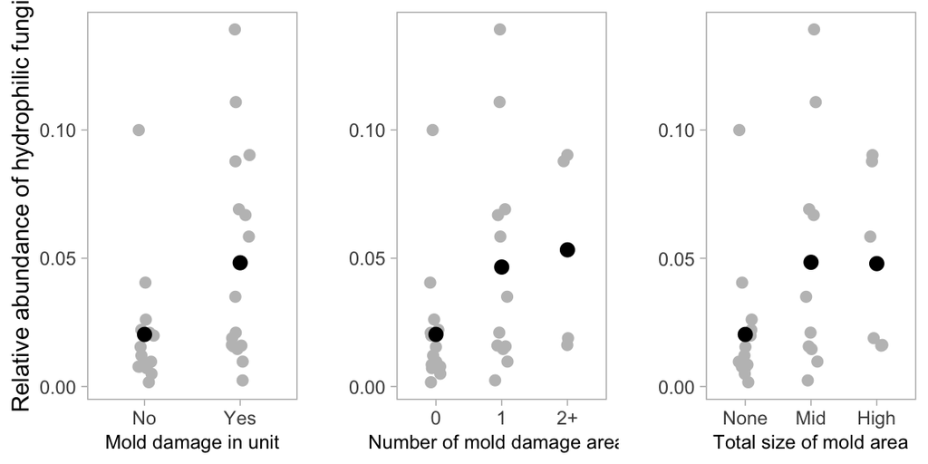

```r
tabs = c("~/Desktop/Targeted-fungi/processed_data/winter.vacuum.hydro.ps.RDS")  #whichever phyloseq object you want to look
ps.object = readRDS(tabs[1])
dat1.pre = cbind.data.frame(name = sample_data(ps.object)$name, Y = sample_data(ps.object)$Y,
    nReads = sample_data(ps.object)$nReads, Y.ra = sample_data(ps.object)$Y.ra,
    mold_dam_in_unit = sample_data(ps.object)$mold_dam_in_unit, num_discrete_mold_areas_cat = sample_data(ps.object)$num_discrete_mold_areas_cat,
    mold_size_in_unit_cat = sample_data(ps.object)$mold_size_in_unit_cat,
    dam_index = as.factor(sample_data(ps.object)$dam_index), total_dam_in_unit = sample_data(ps.object)$total_dam_in_unit,
    num_discrete_dam_areas_cat = sample_data(ps.object)$num_discrete_dam_areas_cat,
    total_dam_size_in_unit_cat = sample_data(ps.object)$total_dam_size_in_unit_cat,
    num_mmr_cat_binary = sample_data(ps.object)$num_mmr_cat_binary)
dat1.pre$total_dam_size_in_unit_cat = factor(dat1.pre$total_dam_size_in_unit_cat,
    levels = c("0", "mid", "high"))
dat1.pre$num_mmr_cat_binary[dat1.pre$num_mmr_cat_binary == "NA"] <- NA
dat1.pre = add_column(dat1.pre, Offset = log(dat1.pre$nReads), .after = "Y.ra")
dat1 = dat1.pre[dat1.pre$nReads > 1000, ]
# excluding the hydro sample dominated by Rhodotorula mucilaginosa
dat1 = dat1[dat1$Y.ra < 0.6, ]

a = ggplot(data = dat1, aes(x = mold_dam_in_unit, y = Y.ra)) + geom_jitter(width = 0.1,
    color = "gray75", size = 2) + theme_light() + theme(panel.grid.minor = element_blank(),
    panel.grid.major = element_blank(), axis.title.x = element_text(size = 9)) +
    stat_summary(fun = mean, geom = "point", shape = 16, size = 3, color = "black") +
    xlab("Mold damage in unit") + ylab("Relative abundance of hydrophilic fungi") +
    scale_x_discrete(breaks = c("no", "yes"), labels = c("No", "Yes"))

b = ggplot(data = dat1, aes(x = num_discrete_mold_areas_cat, y = Y.ra)) +
    geom_jitter(width = 0.1, color = "gray75", size = 2) + theme_light() +
    theme(panel.grid.minor = element_blank(), panel.grid.major = element_blank(),
        axis.title.x = element_text(size = 9)) + stat_summary(fun = mean,
    geom = "point", shape = 16, size = 3, color = "black") + xlab("Number of mold damage areas") +
    ylab("") + scale_x_discrete(breaks = c("0", "1", "2"), labels = c("0",
    "1", "2+"))

c = ggplot(data = dat1, aes(x = mold_size_in_unit_cat, y = Y.ra)) + geom_jitter(width = 0.1,
    color = "gray75", size = 2) + theme_light() + theme(panel.grid.minor = element_blank(),
    panel.grid.major = element_blank(), axis.title.x = element_text(size = 9)) +
    stat_summary(fun = mean, geom = "point", shape = 16, size = 3, color = "black") +
    xlab("Total size of mold area") + ylab("") + scale_x_discrete(breaks = c("0",
    "1", "2"), labels = c("None", "Mid", "High"))

plot_grid(a, b, c, ncol = 3, nrow = 1)
```

```r
ggsave("~/Desktop/Targeted-fungi/outputs/hydro-vacuum-high_res.pdf", width = 7,
    height = 3.5, units = "in", dpi = 600)
```